# 教師あり学習によるアワビの年齢予測

以下のURLからデータを読み込み，アワビの年齢を予測する機械学習モデルを作成しました．

http://archive.ics.uci.edu/ml/machine-learning-databases/abalone/abalone.data

## 目次

現在は重回帰分析のみ．随時更新予定

- 1.データの読み込み
- 2.機械学習モデルの実装
  - 2-1.重回帰分析

## 1.データの読み込み

https://archive.ics.uci.edu/ml/datasets/abalone より，データセットの属性を確認  
Attribute Information:

Given is the attribute name, attribute type, the measurement unit and a brief description. The number of rings is the value to predict: either as a continuous value or as a classification problem.

Sex / nominal / -- / M, F, and I (infant)  
Length / continuous / mm / Longest shell measurement  
Diameter / continuous / mm / perpendicular to length  
Height / continuous / mm / with meat in shell  
Whole weight / continuous / grams / whole abalone  
Shucked weight / continuous / grams / weight of meat  
Viscera weight / continuous / grams / gut weight (after bleeding)  
Shell weight / continuous / grams / after being dried  
Rings / integer / -- / +1.5 gives the age in years

今回の目的はアワビの年齢を予測することなので，目的変数$y$は`Ring`となる

```python
#データの読み込み
import requests, zipfile
import io
import pandas as pd
import numpy as np
import seaborn as sns

%matplotlib inline

url = 'http://archive.ics.uci.edu/ml/machine-learning-databases/abalone/abalone.data'

res = requests.get(url).content

# 取得したデータをDataFrameオブジェクトとして読み込み
Abalone = pd.read_csv(io.StringIO(res.decode('utf-8')), header=None)
#列名の設定
Abalone.columns =[
    'Sex', 'Length', 'Diameter', 'Height',
    'Whole weight', 'Shucked weight', 'Viscera weight', 'Shellweight', 'Ring'
]

#データのサイズを出力
print(Abalone.shape)

#欠損値の確認
print(Abalone.isnull().sum())

Abalone.head()
```

```
(4177, 9)
Sex               0
Length            0
Diameter          0
Height            0
Whole weight      0
Shucked weight    0
Viscera weight    0
Shellweight       0
Ring              0
dtype: int64
```

|  | Sex | Length | Diameter | Height | Whole weight | Shucked weight | Viscera weight | Shellweight | Ring |
| --- | --- | --- | --- | --- | --- | --- | --- | --- | --- |
| 0 | M | 0.455 | 0.365 | 0.095 | 0.5140 | 0.2245 | 0.1010 | 0.150 | 15 |
| 1 | M | 0.350 | 0.265 | 0.090 | 0.2255 | 0.0995 | 0.0485 | 0.070 | 7 |
| 2 | F | 0.530 | 0.420 | 0.135 | 0.6770 | 0.2565 | 0.1415 | 0.210 | 9 |
| 3 | M | 0.440 | 0.365 | 0.125 | 0.5160 | 0.2155 | 0.1140 | 0.155 | 10 |
| 4 | I | 0.330 | 0.255 | 0.080 | 0.2050 | 0.0895 | 0.0395 | 0.055 | 7 |

```python
#データの基本統計量をみる
Abalone.describe()
```

|  | Length | Diameter | Height | Whole weight | Shucked weight | Viscera weight | Shellweight | Ring |
| --- | --- | --- | --- | --- | --- | --- | --- | --- |
| count | 4177.000000 | 4177.000000 | 4177.000000 | 4177.000000 | 4177.000000 | 4177.000000 | 4177.000000 | 4177.000000 |
| mean | 0.523992 | 0.407881 | 0.139516 | 0.828742 | 0.359367 | 0.180594 | 0.238831 | 9.933684 |
| std | 0.120093 | 0.099240 | 0.041827 | 0.490389 | 0.221963 | 0.109614 | 0.139203 | 3.224169 |
| min | 0.075000 | 0.055000 | 0.000000 | 0.002000 | 0.001000 | 0.000500 | 0.001500 | 1.000000 |
| 25% | 0.450000 | 0.350000 | 0.115000 | 0.441500 | 0.186000 | 0.093500 | 0.130000 | 8.000000 |
| 50% | 0.545000 | 0.425000 | 0.140000 | 0.799500 | 0.336000 | 0.171000 | 0.234000 | 9.000000 |
| 75% | 0.615000 | 0.480000 | 0.165000 | 1.153000 | 0.502000 | 0.253000 | 0.329000 | 11.000000 |
| max | 0.815000 | 0.650000 | 1.130000 | 2.825500 | 1.488000 | 0.760000 | 1.005000 | 29.000000 |

```python
#各データの相関
Abalone.corr()
```

|  | Length | Diameter | Height | Whole weight | Shucked weight | Viscera weight | Shellweight | Ring |
| --- | --- | --- | --- | --- | --- | --- | --- | --- |
| Length | 1.000000 | 0.986812 | 0.827554 | 0.925261 | 0.897914 | 0.903018 | 0.897706 | 0.556720 |
| Diameter | 0.986812 | 1.000000 | 0.833684 | 0.925452 | 0.893162 | 0.899724 | 0.905330 | 0.574660 |
| Height | 0.827554 | 0.833684 | 1.000000 | 0.819221 | 0.774972 | 0.798319 | 0.817338 | 0.557467 |
| Whole weight | 0.925261 | 0.925452 | 0.819221 | 1.000000 | 0.969405 | 0.966375 | 0.955355 | 0.540390 |
| Shucked weight | 0.897914 | 0.893162 | 0.774972 | 0.969405 | 1.000000 | 0.931961 | 0.882617 | 0.420884 |
| Viscera weight | 0.903018 | 0.899724 | 0.798319 | 0.966375 | 0.931961 | 1.000000 | 0.907656 | 0.503819 |
| Shellweight | 0.897706 | 0.905330 | 0.817338 | 0.955355 | 0.882617 | 0.907656 | 1.000000 | 0.627574 |
| Ring | 0.556720 | 0.574660 | 0.557467 | 0.540390 | 0.420884 | 0.503819 | 0.627574 | 1.000000 |

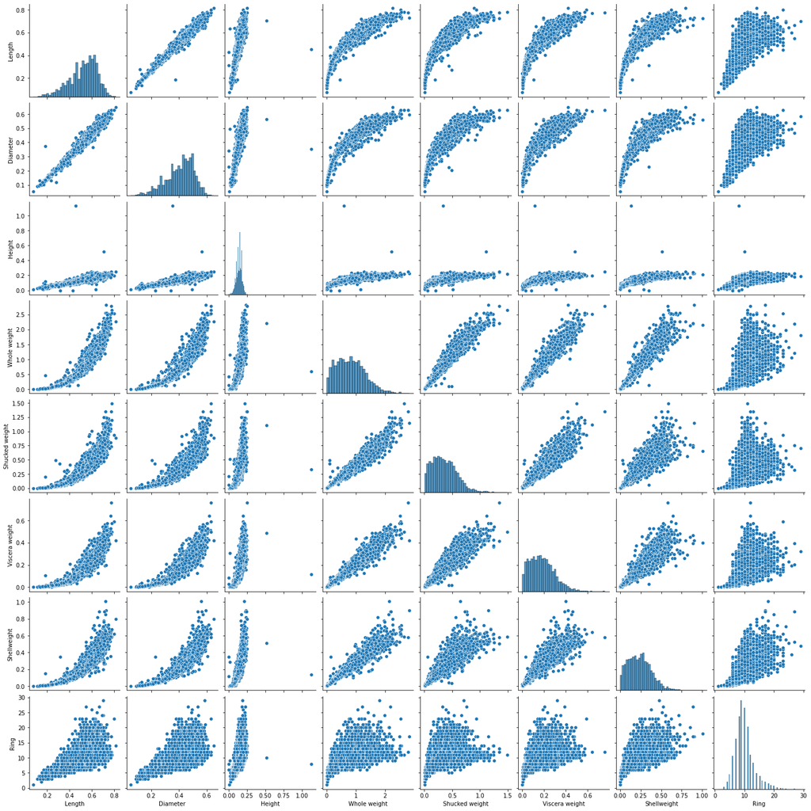

```python
sns.pairplot(Abalone)
```

## 2.機械学習モデルの実装

**現在は重回帰モデルしか実装していませんが，随時更新予定です**

### 2.1重回帰モデル

重回帰モデルに文字データ（`Sex`列）を取り入れるのは難しそうだと考えたので，説明変数$X$を`Length`， `Diameter`， `Height`， `Whole weight`， `Shucked weight`, `Viscera weight`, `Shellweight`の列として重回帰を行う

```python
#モジュールのインポート
from sklearn.linear_model import LinearRegression
from sklearn.model_selection import train_test_split

#目的変数の設定
X = Abalone.drop(['Sex', 'Ring'], axis = 1)
y = Abalone['Ring']

#訓練データとテストデータに分割
X_train, X_test, y_train, y_test = train_test_split(X, y, test_size=0.5, random_state=0)

#重回帰モデルの設定と学習
model = LinearRegression()
model.fit(X_train, y_train)

#テストデータによる検証の表示
print("決定係数（Train）", model.score(X_train, y_train))
print("決定係数（test）", model.score(X_test, y_test))
```

```
決定係数（Train） 0.5317207550808134
決定係数（test） 0.5195978061430893
```

単に(`Sex`列)以外の全てのデータを使って重回帰分析を行なっただけでは，納得いく結果が得られなかった．そこで$X$を平均0，分散1に正規化してみる．

```python
from sklearn.preprocessing import StandardScaler

sc = StandardScaler()
sc.fit(X_train)

X_train_std = sc.transform(X_train)
X_test_std = sc.transform(X_test)


#重回帰モデルの設定と学習
model = LinearRegression()
model.fit(X_train_std, y_train)

#テストデータによる検証の表示
print("決定係数（Train）", model.score(X_train_std, y_train))
print("決定係数（test）", model.score(X_test_std, y_test))
```

```
決定係数（Train） 0.5317207550808134
決定係数（test） 0.5195978061430893
```

正規化によっても決定係数の値が改善しなかったので，説明変数の数を減らしてみる．具体的には`Rings`との相関係数が比較的小さい`Shucked weight`と`Viscera weight`を説明変数から除外する．

```python
X_new = X.drop(['Shucked weight', 'Viscera weight'], axis = 1)
X_train, X_test, y_train, y_test = train_test_split(X_new, y, test_size=0.5, random_state=0)

#正規化
sc = StandardScaler()
sc.fit(X_train)
X_train_std = sc.transform(X_train)
X_test_std = sc.transform(X_test)


#重回帰モデルの設定と学習
model = LinearRegression()
model.fit(X_train_std, y_train)

#テストデータによる検証の表示
print("決定係数（Train）", model.score(X_train_std, y_train))
print("決定係数（test）", model.score(X_test_std, y_test))
```

```
決定係数（Train） 0.4538689580268157
決定係数（test） 0.4596029895579692
```

戻る